# Pilot RQ1 analysis

Author

Risk Rejection Team: Guannan Shen

Published

October 21, 2024

# Understand the Sample

## Sample Filtering

[figure not shown]

## Demographics

**Table 1. Subjects Characteristics**

| **Characteristics** | **N** | **Overall** N = 527 <sup>1</sup> | **Experimental Conditions** **Control** N = 181 <sup>1</sup> | **Experimental Conditions** **Condition a** N = 157 <sup>1</sup> | **Experimental Conditions** **Condition b** N = 189 <sup>1</sup> | **p-value** <sup>2</sup> |  |
| --- | --- | --- | --- | --- | --- | --- | --- |
| Age | 527 | 55.01 (9.90) | 55.25 (9.82) | 56.05 (9.68) | 53.90 (10.09) |  | 0.13 |
| Race/Ethnicity | 527 |  |  |  |  | 0.4 |  |
| 1 |  | 238 (45%) | 82 (45%) | 75 (48%) | 81 (43%) |  |  |
| 2 |  | 185 (35%) | 70 (39%) | 55 (35%) | 60 (32%) |  |  |
| 3 |  | 26 (4.9%) | 10 (5.5%) | 5 (3.2%) | 11 (5.8%) |  |  |
| 4 |  | 57 (11%) | 15 (8.3%) | 15 (9.6%) | 27 (14%) |  |  |
| 5 |  | 21 (4.0%) | 4 (2.2%) | 7 (4.5%) | 10 (5.3%) |  |  |
| PlaceofBirth | 26 |  |  |  |  | 0.8 |  |
| 1 |  | 6 (23%) | 3 (30%) | 1 (20%) | 2 (18%) |  |  |
| 2 |  | 20 (77%) | 7 (70%) | 4 (80%) | 9 (82%) |  |  |
| (Missing) |  | 501 | 171 | 152 | 178 |  |  |
| Asian/AA | 57 |  |  |  |  | 0.9 |  |
| 6 |  | 13 (23%) | 3 (20%) | 3 (20%) | 7 (26%) |  |  |
| 7 |  | 6 (11%) | 1 (6.7%) | 1 (6.7%) | 4 (15%) |  |  |
| 8 |  | 10 (18%) | 3 (20%) | 4 (27%) | 3 (11%) |  |  |
| 11 |  | 28 (49%) | 8 (53%) | 7 (47%) | 13 (48%) |  |  |
| (Missing) |  | 470 | 166 | 142 | 162 |  |  |
| FirstMenses | 527 |  |  |  |  | 0.8 |  |
| 7 |  | 152 (29%) | 47 (26%) | 45 (29%) | 60 (32%) |  |  |
| 12 |  | 266 (50%) | 95 (52%) | 81 (52%) | 90 (48%) |  |  |
| 14 |  | 109 (21%) | 39 (22%) | 31 (20%) | 39 (21%) |  |  |
| FirstChild | 527 |  |  |  |  | 0.8 |  |
| 19 |  | 97 (18%) | 41 (23%) | 26 (17%) | 30 (16%) |  |  |
| 20 |  | 126 (24%) | 44 (24%) | 38 (24%) | 44 (23%) |  |  |
| 25 |  | 85 (16%) | 30 (17%) | 26 (17%) | 29 (15%) |  |  |
| 30 |  | 88 (17%) | 27 (15%) | 28 (18%) | 33 (17%) |  |  |
| 98 |  | 129 (24%) | 38 (21%) | 38 (24%) | 53 (28%) |  |  |
| 99 |  | 2 (0.4%) | 1 (0.6%) | 1 (0.6%) | 0 (0%) |  |  |
| family_history | 527 |  |  |  |  | 0.8 |  |
| 0 |  | 372 (71%) | 131 (72%) | 108 (69%) | 133 (70%) |  |  |
| 1 |  | 93 (18%) | 31 (17%) | 28 (18%) | 34 (18%) |  |  |
| 2 |  | 41 (7.8%) | 11 (6.1%) | 13 (8.3%) | 17 (9.0%) |  |  |
| 99 |  | 21 (4.0%) | 8 (4.4%) | 8 (5.1%) | 5 (2.6%) |  |  |
| biopsy | 527 |  |  |  |  | 0.4 |  |
| 0 |  | 434 (82%) | 147 (81%) | 127 (81%) | 160 (85%) |  |  |
| 1 |  | 83 (16%) | 30 (17%) | 25 (16%) | 28 (15%) |  |  |
| 2 |  | 10 (1.9%) | 4 (2.2%) | 5 (3.2%) | 1 (0.5%) |  |  |
| num_biopsies | 83 |  |  |  |  | 0.4 |  |
| 1 |  | 66 (80%) | 22 (73%) | 22 (88%) | 22 (79%) |  |  |
| 2 |  | 17 (20%) | 8 (27%) | 3 (12%) | 6 (21%) |  |  |
| (Missing) |  | 444 | 151 | 132 | 161 |  |  |
| hyperplasia | 83 |  |  |  |  | 0.4 |  |
| 0 |  | 40 (48%) | 13 (43%) | 16 (64%) | 11 (39%) |  |  |
| 1 |  | 14 (17%) | 5 (17%) | 4 (16%) | 5 (18%) |  |  |
| 2 |  | 29 (35%) | 12 (40%) | 5 (20%) | 12 (43%) |  |  |
| (Missing) |  | 444 | 151 | 132 | 161 |  |  |

<sup>1</sup> Mean (SD); n (%)  
<sup>2</sup> One-way analysis of means (not assuming equal variances); Pearson’s Chi-squared test; Fisher’s exact test

# Research Question 1

**The question: Does asking about people’s perceived risk of developing breast cancer prior to providing their risk estimate affect the likelihood of them expressing risk skepticism?**

Conduct an experiment with 3 conditions, randomly assigned in a 1:1:1 allocation:

1. Risk perceptions measured before participants viewed the Gail model risk questions vs.
2. Risk perceptions measured after participants viewed the Gail model risk questions but before they viewed the results vs.
3. Risk perceptions measured after participants viewed their risk results.

Where **c** is the control group, and group **a, b, c** correspond to 1, 2, 3 in the Experimental condition variable.

## Question Breakdown

- 1. Start with measures of central tendency for all risk skepticism measures, because we are going to want to talk about what will be our primary outcome for the longitudinal survey. (**Diagnostics**)
- 2. Three models with experimental condition as predictor, and 3 ways of measuring risk skepticism as outcomes.
1. Open text box (RReject_diff = RReject1 - abs_risk_rounded).
2. comparative risk (Combination of RReject3 and Abs_risk_relative_risk).
3. Disbelief questions from Scherer et al. R37 (average of rreject4-rreject7).

## Simple Linear regression

### Results Summary

RReject1 on the scale 0-1000. Higher means high risk.

RReject3:

1 = I think my risk is higher than the average woman my age.,

2 = I think my risk is about the same as the average woman my age.,

3 = I think my risk is lower than the average woman my age.

RReject4 - 7:

1 = Disagree a lot,

2 = Disagree a little,

3 = Neither agree nor disagree,

4 = Agree a little,

5 = Agree a lot.

The following table shows the estimates of coefficients and corresponding standard errors. The F statistic is the overall test as the ANOVA test (**There is no significant correlation as shown below**).

```
Linear Regression Results for RRejectAbsand RRejects Average
===================================================================================
                                               Dependent variable:
                               ----------------------------------------------------
                                 RReject_diff    Abs_RReject_diff    RReject_mean
                                     (1)               (2)               (3)
-----------------------------------------------------------------------------------
ConditionCondition a           13.263 (15.669)   13.040 (15.431)    -0.007 (0.121)
ConditionCondition b            7.973 (14.942)    8.772 (14.715)    0.028 (0.115)
Constant                       20.202* (10.679) 29.699*** (10.517) 3.436*** (0.083)
-----------------------------------------------------------------------------------
Observations                         527               527               527
R2                                  0.001             0.001             0.0002
Adjusted R2                         -0.002            -0.002            -0.004
Residual Std. Error (df = 524)     143.676           141.491            1.110
F Statistic (df = 2; 524)           0.368             0.379             0.048
===================================================================================
Note:                                                   *p<0.1; **p<0.05; ***p<0.01
```

### Diagnostic Plot

Diagnostic Plots for RReject_diff, Abs_RReject_diff, and RRejects Average respectively.

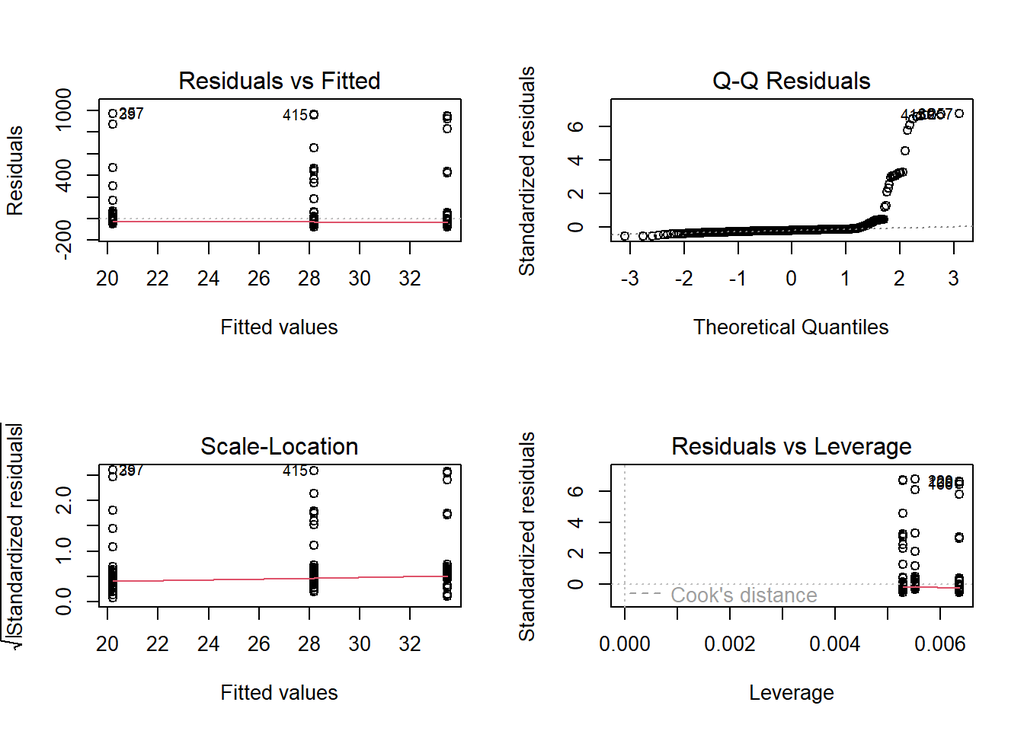

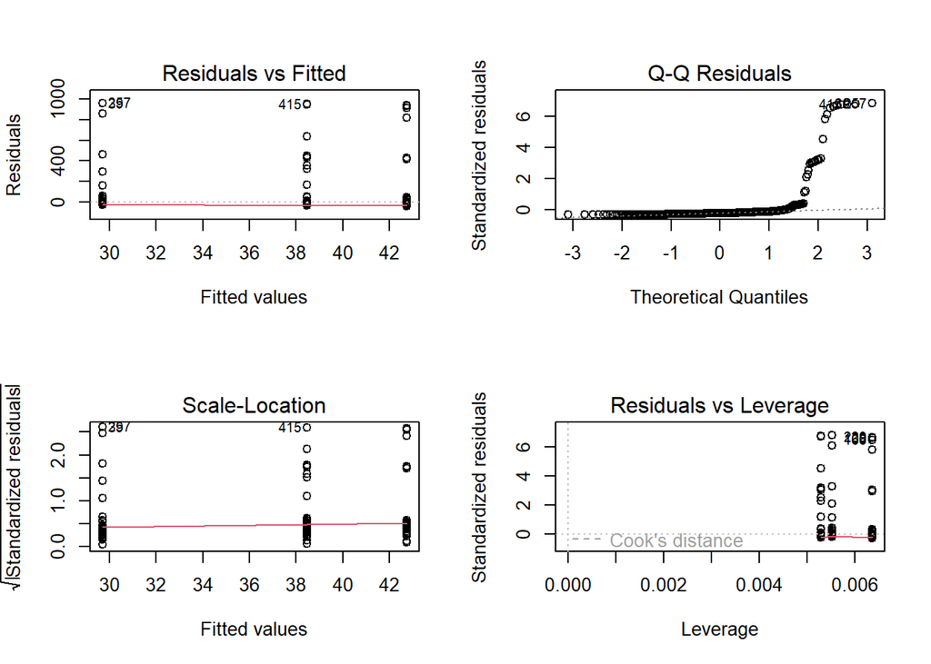

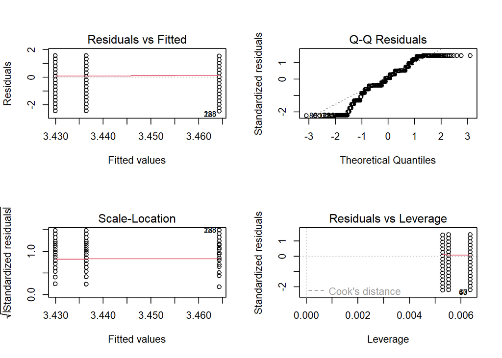

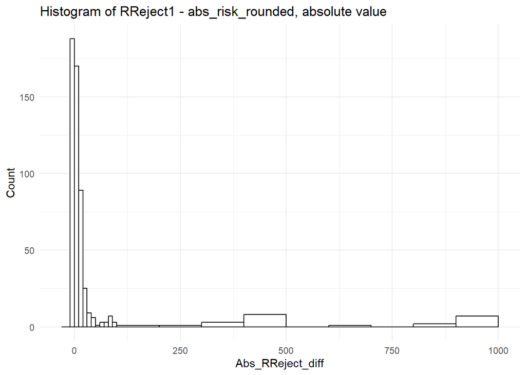

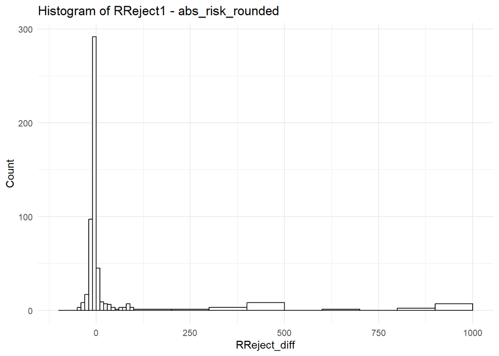

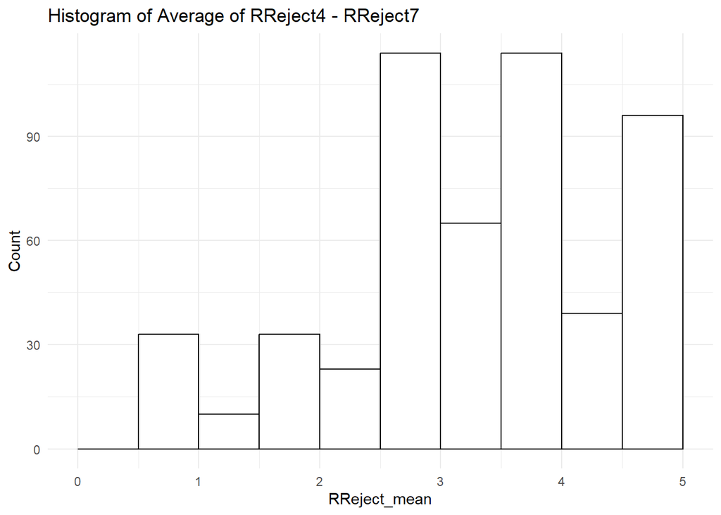

## Chi-squared test of Comparative Risk Skepticism and Condition

Conduct an experiment with 3 conditions, randomly assigned in a 1:1:1 allocation:

1. Risk perceptions measured before participants viewed the Gail model risk questions vs.
2. Risk perceptions measured after participants viewed the Gail model risk questions but before they viewed the results vs.
3. Risk perceptions measured after participants viewed their risk results.

|  | **Condition** Control | **Condition** Condition a | **Condition** Condition b | **Total** |  |
| --- | --- | --- | --- | --- | --- |
| RReject_comp_1 |  |  |  |  |  |
| very underestimate, higher than | 24 (4.6%) | 24 (4.6%) | 18 (3.4%) | 66 (13%) |  |
| underestimate, about the same as | 30 (5.7%) | 13 (2.5%) | 11 (2.1%) | 54 (10%) |  |
| underestimate, higher than | 46 (8.7%) | 42 (8.0%) | 69 (13%) | 157 (30%) |  |
| accurate estimate | 72 (14%) | 70 (13%) | 81 (15%) | 223 (42%) |  |
| overestimate, lower than | 7 (1.3%) | 6 (1.1%) | 6 (1.1%) | 19 (3.6%) |  |
| overestimate, about the same as | 2 (0.4%) | 2 (0.4%) | 3 (0.6%) | 7 (1.3%) |  |
| very overestimate, lower than | 0 (0%) | 0 (0%) | 1 (0.2%) | 1 (0.2%) |  |
| Total | 181 (34%) | 157 (30%) | 189 (36%) | 527 (100%) |  |

```
    Fisher's Exact Test for Count Data with simulated p-value (based on
    2000 replicates)

data:  table(df$RReject_comp_1, df$Condition)
p-value = 0.04998
alternative hypothesis: two.sided
```

|  | **Condition** Control | **Condition** Condition a | **Condition** Condition b | **Total** | **p-value** <sup>1</sup> |  |  |
| --- | --- | --- | --- | --- | --- | --- | --- |
| RReject_comp_2 |  |  |  |  |  |  | 0.6 |
| very underestimate | 24 (4.6%) | 24 (4.6%) | 18 (3.4%) | 66 (13%) |  |  |  |
| underestimate | 76 (14%) | 55 (10%) | 80 (15%) | 211 (40%) |  |  |  |
| accurate estimate | 72 (14%) | 70 (13%) | 81 (15%) | 223 (42%) |  |  |  |
| overestimate | 9 (1.7%) | 8 (1.5%) | 9 (1.7%) | 26 (4.9%) |  |  |  |
| very overestimate | 0 (0%) | 0 (0%) | 1 (0.2%) | 1 (0.2%) |  |  |  |
| Total | 181 (34%) | 157 (30%) | 189 (36%) | 527 (100%) |  |  |  |

<sup>1</sup> Fisher’s exact test

|  | **Condition** Control | **Condition** Condition a | **Condition** Condition b | **Total** | **p-value** <sup>1</sup> |  |  |
| --- | --- | --- | --- | --- | --- | --- | --- |
| RReject_comp_3 |  |  |  |  |  |  | >0.9 |
| underestimate | 100 (19%) | 79 (15%) | 98 (19%) | 277 (53%) |  |  |  |
| accurate estimate | 72 (14%) | 70 (13%) | 81 (15%) | 223 (42%) |  |  |  |
| overestimate | 9 (1.7%) | 8 (1.5%) | 10 (1.9%) | 27 (5.1%) |  |  |  |
| Total | 181 (34%) | 157 (30%) | 189 (36%) | 527 (100%) |  |  |  |

<sup>1</sup> Pearson’s Chi-squared test

## 0 truncated linear regression for Abs_RReject_diff and Condition (for reference)

In the truncated linear regression model, there isn’t a direct equivalent to the F-statistic that you would see in a standard linear regression model. In linear regression, the F-statistic tests whether the overall model is significantly better than a model with no predictors.

```
Call:
truncreg(formula = Abs_RReject_diff ~ Condition, data = df, point = 0,
    direction = "left")

BFGS maximization method
52 iterations, 0h:0m:0s
g'(-H)^-1g =  37.3



Coefficients :
                      Estimate Std. Error t-value Pr(>|t|)
(Intercept)          -1732.364    182.599 -9.4872  < 2e-16 ***
ConditionCondition a  -302.686    250.507 -1.2083  0.22693
ConditionCondition b  -442.297    248.707 -1.7784  0.07534 .
sigma                  292.978     15.554 18.8365  < 2e-16 ***
---
Signif. codes:  0 '***' 0.001 '**' 0.01 '*' 0.05 '.' 0.1 ' ' 1

Log-Likelihood: -2494.5 on 4 Df
```

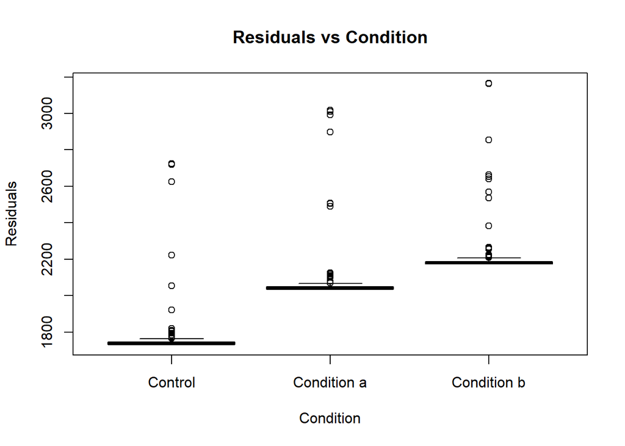

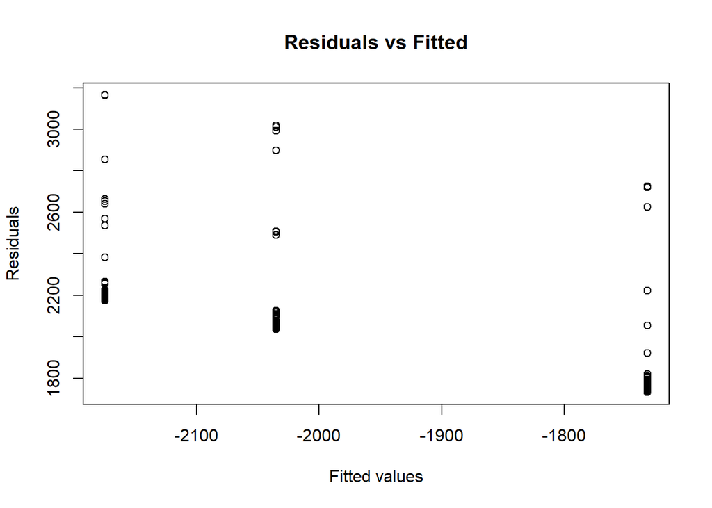

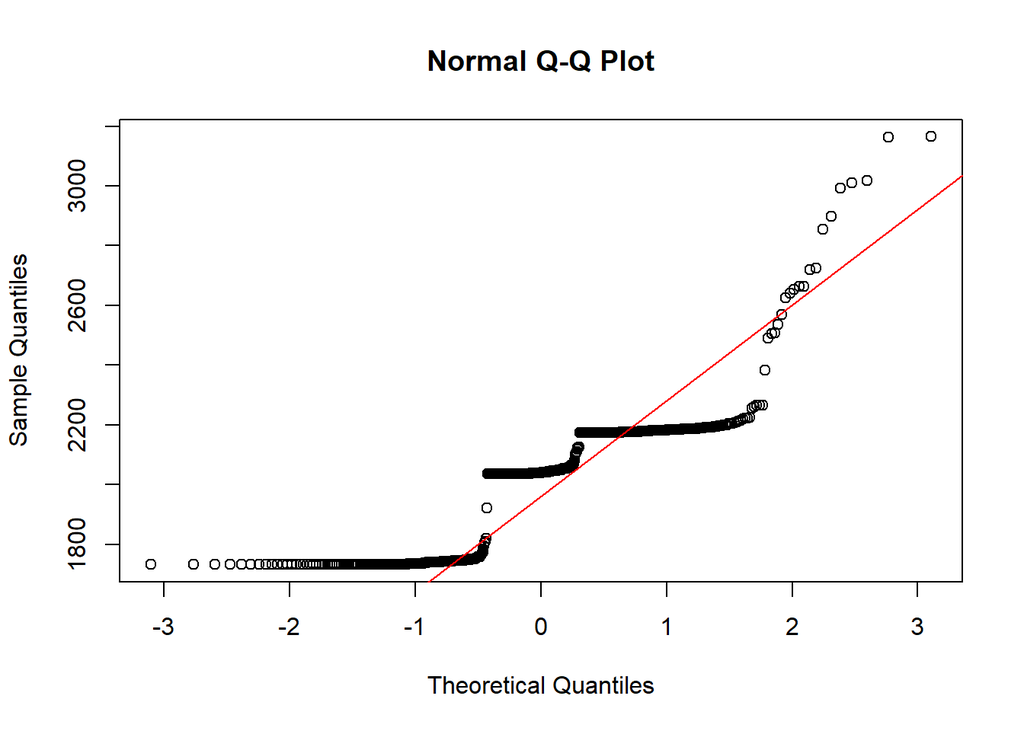

The coefficients reflect the relationship only for the observed part of the data (i.e., the portion of the outcome variable that is greater than 0). These coefficients appear larger because the model is adjusting for the fact that part of the data is missing due to truncation.

# Subject Numeracy

Subject numeracy:

- Q1: How good are you at working with fractions?
- Q2: How good are you at figuring out how much a shirt will cost if it is 25% off?
- Q3: How often do you find numerical information to be useful?

1 = Not at all good / 6 = Extremely good

1 = Never / 6 = Very often

## Exploratory and Linear Regression

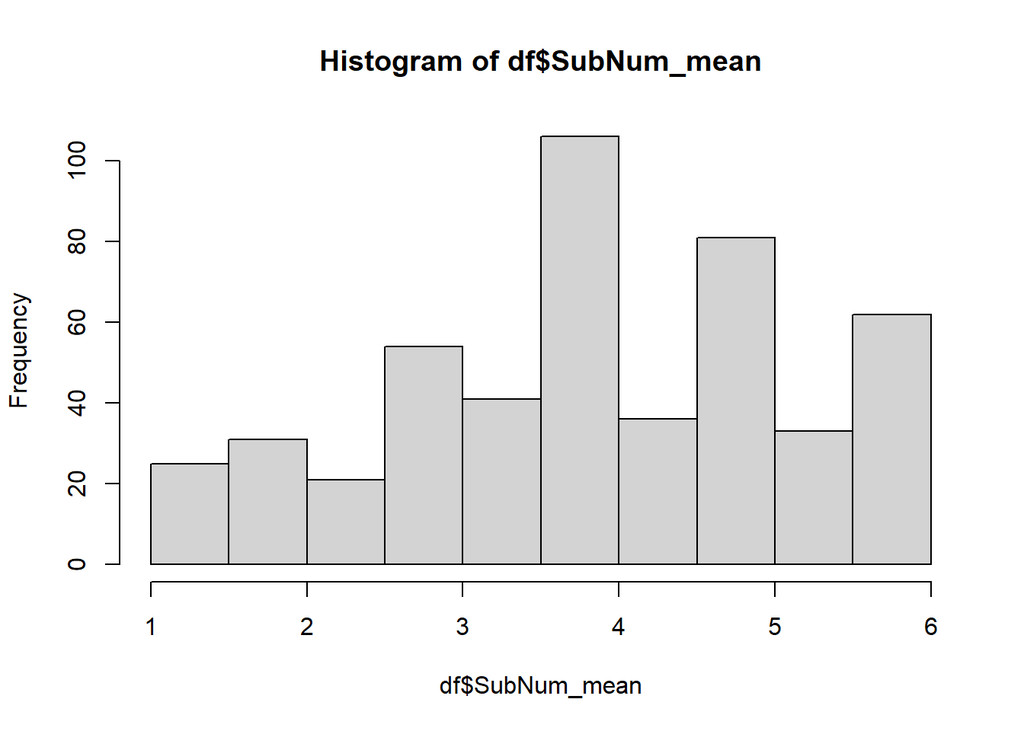

| **Characteristic** | **N** | **N = 527** <sup>1</sup> |
| --- | --- | --- |
| RReject_diff_attitude | 527 |  |
| Not Totally Agree |  | 339 (64%) |
| Totally Agree |  | 188 (36%) |

<sup>1</sup> n (%)

```
Linear Models: RRejectand Abs
==========================================================================
                                             Dependent variable:
                                   ---------------------------------------
                                      RReject_diff      Abs_RReject_diff
                                           (1)                 (2)
--------------------------------------------------------------------------
SubNum_mean                           2.219 (5.092)       1.902 (4.970)
RReject_diff_attitudeTotally Agree -45.107*** (13.796) -60.277*** (13.467)
Constant                            36.439* (21.694)    52.846** (21.176)
--------------------------------------------------------------------------
Observations                               490                 490
R2                                        0.022               0.040
Adjusted R2                               0.018               0.036
Residual Std. Error (df = 487)           147.038             143.531
F Statistic (df = 2; 487)               5.455***            10.108***
==========================================================================
Note:                                          *p<0.1; **p<0.05; ***p<0.01
```

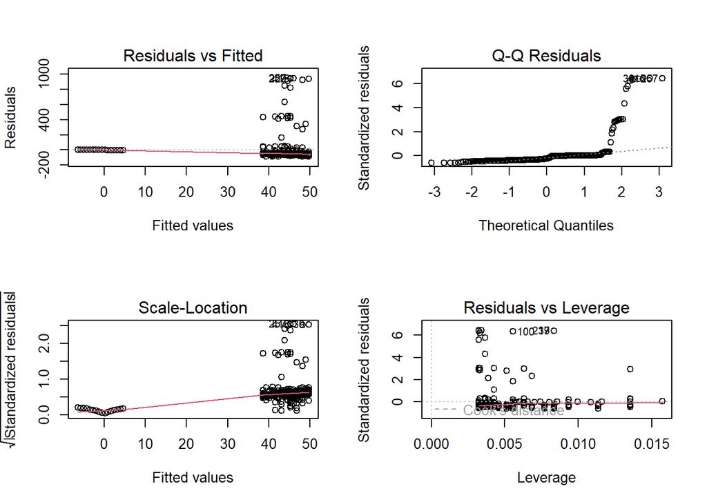

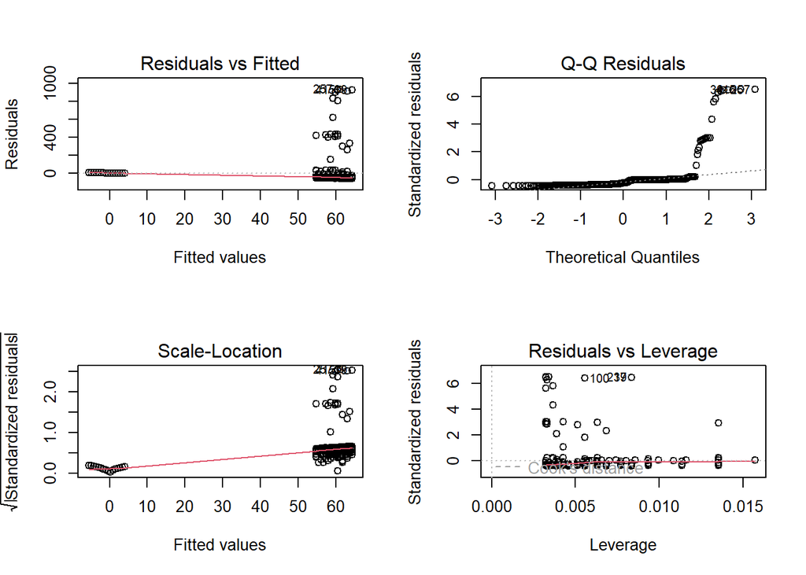

## Truncated Linear Regression

```
Call:
truncreg(formula = Abs_RReject_diff ~ SubNum_mean + RReject_diff_attitude,
    data = df, point = 0, direction = "left")

BFGS maximization method
50 iterations, 0h:0m:0s
g'(-H)^-1g =  -7.7



Coefficients :
                                   Estimate Std. Error t-value  Pr(>|t|)
(Intercept)                        -289.729    302.463 -0.9579    0.3381
SubNum_mean                        -687.859        NaN     NaN       NaN
RReject_diff_attitudeTotally Agree -532.934     87.777 -6.0715 1.267e-09 ***
sigma                               360.518        NaN     NaN       NaN
---
Signif. codes:  0 '***' 0.001 '**' 0.01 '*' 0.05 '.' 0.1 ' ' 1

Log-Likelihood: -2318.3 on 4 Df
```